# Project 1

November 25, 2018

### Background

The data that I am using is a dataset from Kickstarter (a crowdfunding platform) that includes over 30,000 kickstarter projects. The dataset has been filtered to include kickstarter projects that were only funded in US dollars. This dataset came from Kaggle can be found through the following link: https://www.kaggle.com/kemical/kickstarter-projects

### Questions and Hypotheses

Below I wrote the questions that I am trying to find answers to and their hypothesis. The first question I will use a Kruskal-Wallis test to solve, the second question I will use a Wilcoxon test, and the last question I will be using a linear regression to solve. The significance level for all of the three following questions will be set to an $\alpha = .05$.

##### Question 1:

Does each category of kickstarter projects have pledged amounts that come from the same distribution? (i.e. does one of the kickstarter projects mean pledged amount given exceed that of other projects)

I will be using a Kruskal-Wallis test since the distribution is not normal (as can be seen in the “Appropriatness of the data” section below) and there is more than two factors that I am comparing. If the distribution was normal, I would be using an ANOVA.

$H_o: \mu_{category1} = \mu_{category2} ... = \mu_{category15}$

$H_a: \mu_i ≠ \mu \ for \ at \ least \ one \ i$

##### Question 2:

Is there a difference between the amount pledged that successful projects vs. failures receive?

I will be using a wilcoxon test to find the answer to this question.

$H_0: \text{median of differences} = 0$

$H_a: \text{median of differences} \ \left\{\underset{<}{\stackrel{>}{\neq}}\right\} \ 0$

##### Question 3:

Is there a correlation between the goal amount and the amount that was pledged?

For this test I will be using a linear regression.

$H_o: \beta_1 = 0$

$H_a: \beta_1≠ 0$

$\alpha = .05$

## Analysis

### Question 1: Categories and the amounts pledged

Kruskal-Wallis rank sum test: `pledged` by `as.factor(main_category)`

| Test statistic | df | P value |
| --- | --- | --- |
| 9008 | 14 | 0 * * * |

The p-value is significant, which shows that at least one of the categories has a significantly different amount pledged to it than the other categories.

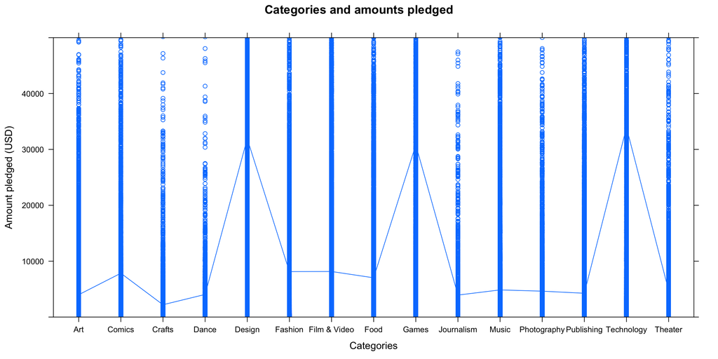

From the graphs above it is apparent that the design, games, and the tech are the top 3 categories that get the most amount pledged. According to the p value from the kruskal test above, this is significant.

### Question 2: States of the project and the amounts pledged

Wilcoxon rank sum test with continuity correction: `pledged` by `as.factor(state)`

| Test statistic | P value | Alternative hypothesis |
| --- | --- | --- |
| 1495031768 | 0 * * * | two.sided |

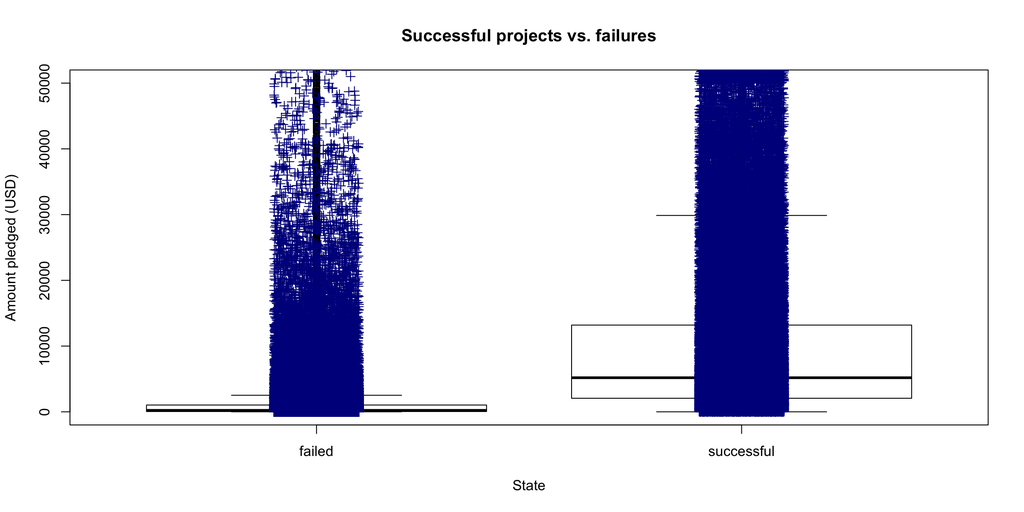

As can be seen from the boxplots above, the successful projects typically have more money pledged to them, this makes sense since those projects that are worth funding are probably going to attract more attention and money. Also, for clarification purposes, the definition of success and failure is that if a project is successful, the project is built/occurs and if it is a failure, then funders get their money back.

### Question 3: Linear regression of goal and amount pledged

Table continues below

|  | Estimate | Std. Error | t value |
| --- | --- | --- | --- |
| **(Intercept)** | 33032 | 1927 | 17.14 |
| **pledged** | 0.07533 | 0.01727 | 4.362 |

|  | Pr(>\|t\|) |
| --- | --- |
| **(Intercept)** | 0.000000000000000000000000000000000000000000000000000000000000000008353 |
| **pledged** | 0.0000129 |

Fitting linear model: goal ~ pledged

| Observations | Residual Std. Error | $R^2$ | Adjusted $R^2$ |
| --- | --- | --- | --- |
| 232620 | 924356 | 0.00008178 | 0.00007748 |

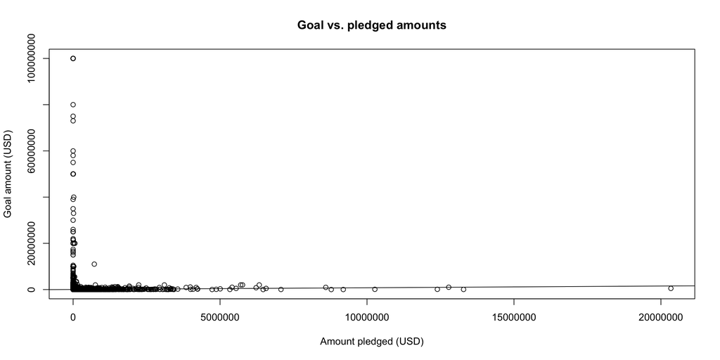

### Appropriateness of the data

It is important to check if the data is normal or not, since if it was normal, then an ANOVA test would have been more appropriate.

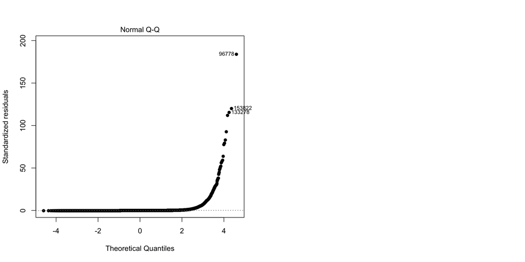

As you can see from the diagnostic chart above, the Kruskal Wallis test was appropriate because the data was not normal.

Since the data was not normal, a wilcox test was used for question 2 instead of an independent t test.

### Conclusion

I was surprised to see that all of the values were significant in the dataset. The categories came from different distributions in the end, which is what I expected, I just wasn’t sure which categories would be most popular (technology was one I guessed, but I would have never guessed design). For the second test, if there was a difference, I expected the failed projects to get more money since there would be more of them, but it turns out that the successful projects received a significantly larger amount of money. Also I wasn’t expecting the relationship between the goal and amount pledged to be so right skewed either. Finally, it did make sense that the successful project would get, on average, more funds given to them.